# Labour market concentration and minimum wage impacts

Author

Published

January 03, 2026, 09:01 +0900

# 1 Introduction

# 2 Agricultural minimum wages in South Africa

# 3 Previous work

Since the late 1990’s, there has been a long debate on the employment impacts of minimum wages. The traditional view under a competitive labour market expected that the employment will be reduced with an increased level of minimum wages. The expectation did not match the empirical results, however. Summaries of evidence suggest that the employment impacts are relatively small, if they exist (Manning 2021b; Dube and Lindner 2024).

It has always been argued that labour markets may not be competitive (Robinson 1933; Manning 2013, 2021a). An early work discussed multiple channels that firms can adjust with, and firms can choose not to adjust on labour (MaCurdy 2015). Even after narrowing the channel to labour market transactions, oligopsonistic firms still have a few options: laying off workers, labour-labour substituion[^1] (Horton 2025), or reducing the firm’s labour market transaction margins (wage markdowns). However, relatively few studies examine the adjustment channels beyond lay offs. This study aims to examine the plausibility of shrinking labour market margins. Azar et al. (2023) are the first to examin this channel and use online labour market data of store clerks for the US wide representativeness. They find that HHI softens the possible unemployment impacts of minimum wages.

# 4 Monopsony and unemployent impacts

We test if the labour market concentration, a proxy for labour market power, reduces the unemployment impacts of minimum wages. Under a standard theory, oligopsonistic firms can mitigate unemployment impacts of minimum wages through two channels: Increased labour supply and reduced wage markdowns (Bhaskar, Manning, and To 2002) (see Section 4.1).

The minimum wage for a monopsonist effectively transforms an upward sloping labour supply curve to a horizontal line. When the minimum wage is set lower than the competitive wage at the competitive employment level, it can result in an increased level of employment. In reality, marginal revenue curves differ across firms and there is an additional pressure on firms through competition between firms on the labour demand side, which dilute the positive employment response. Firms with low marginal revenue curves may exit the market. The end result is thus either negative or positive, while the scale of the impact may be muted from the pure competitive case or the pure monopsonist case.

# 5 Data

# 6 Estimation strategy

We estimate:
$$\begin{equation}
y_{jrt} = a_{0}+a_{1t}FA_{jr0}+a_{2t}H_{jr0}+a_{3t}FA_{jr0}H_{jr0}+c_{j}+c_{t}+e_{jrt}
\label{esteqn}
\end{equation}$$
For worker $i$, firm $j$ in region $r$ in period $t$, $y_{jrt}$ is an outcome variable, $FA_{jr0}$ is a fraction of affected workers among all workers or a treatment exposure rate at period zero, $H_{jr0}$ is Harfindahl-Hirschman Index of employment in region $r$ at period zero, $c_{j}$ and $c_{t}$ are two-way fixed effects in firms and periods, and $e_{jrt}$ is an idiosyncratic error. $a_{1t}$ captures the classical wage increase impacts which we expect to be negative, and $a_{3t}$ gives the estimate of interest, the unemployment reduction impacts of labour market concentration. We follow Harasztosi and Lindner (2019) in transforming the LHS of $\eqref{esteqn}$ in percentages, so $a_{1}$ becomes an elasticity of the minimum wage and $a_{3}$ is the change in the elasticity.

The underlying identification assumption behind $\eqref{esteqn}$ is the common trend at all levels of $y_{jrt}$. Our justification is that we assume the economy is in the steady state, so the all level variables grow at the same rate for all firms. Empirically, it suffices to have the firm’s outcome growth to follow some probability distribution with the common mean. We allow the estimated coefficients to be time variant. This gives an event-study like interpretation of the estimated impacts. Given the dynamic adjustment process of firms, this flexibility will give us more nuanced interpretation of impacts.

## 6.1 Impacts of minimum wages

# 7 Results

## 7.1 Main results

## 7.2 Robustness checks

## 4.1 Monopsonist responses to a minimum wage

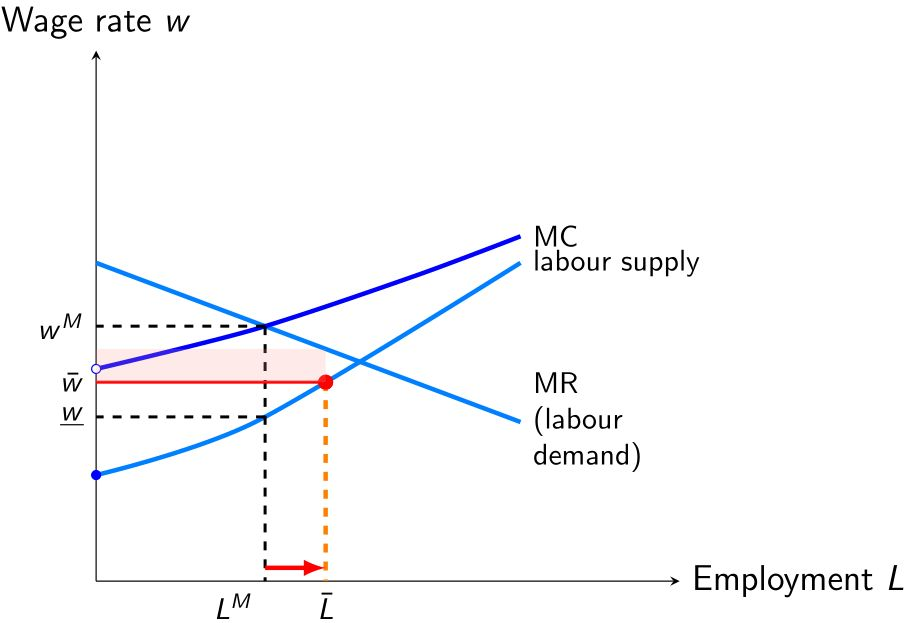

Figure 1: Monopsonist responses to a minimum wage

Let us consider the monoposonist case for simplicity in Figure 1. Prior to minimum wage imposition, profit-maximising employment is chosen at $L^{M}$ while the competitive employment is given at the level where $MR$ and labour supply curve intersect. Monopsonist employment is smaller than competitive employment. The wage markdown is given by $\frac{w^{M}}{\underline{w}}>1$.

When the minimum wage is imposed at $\bar{w}$, the labour supply curve changes to the horizontal line at $\bar{w}$ for employment levels less than $\bar{L}$, because it is above the original labour supply curve. This means that the monopsonist will face an increased labour supply schedule. This leads to an increased employment which is accompanied by the reduced wage markdown from $\frac{w^{M}}{\underline{w}}$ to $\frac{MR(\bar{L})}{\bar{w}}$.

## 8 Conclusion

Azar, José, Emiliano Huet-Vaughn, Ioana Marinescu, Bledi Taska, and Till von Wachter. 2023. “Minimum wage employment effects and labour market concentration.” *The Review of Economic Studies* 91 (4): 1843–83. https://doi.org/10.1093/restud/rdad091.

Bhaskar, Venkataraman, Alan Manning, and Ted To. 2002. “Oligopsony and Monopsonistic Competition in Labor Markets.” *Journal of Economic Perspectives* 16 (2): 155–74.

Dube, Arindrajit, and Attila Lindner. 2024. “Minimum Wages in the 21st Century.” In, edited by Christian Dustmann and Thomas Lemieux, 5:261–383. Handbook of Labor Economics. Elsevier. https://doi.org/10.1016/bs.heslab.2024.11.004.

Harasztosi, Péter, and Attila Lindner. 2019. “Who Pays for the Minimum Wage?” *American Economic Review* 109 (8): 2693–2727.

Horton, John J. 2025. “Price Floors and Employer Preferences: Evidence from a Minimum Wage Experiment.” *American Economic Review* 115 (1): 117–46. https://doi.org/10.1257/aer.20170637.

MaCurdy, Thomas. 2015. “How Effective Is the Minimum Wage at Supporting the Poor?” *Journal of Political Economy* 123 (2): 497–545. https://doi.org/10.1086/679626.

Manning, Alan. 2013. *Monopsony in Motion: Imperfect Competition in Labor Markets*. Princeton University Press.

———. 2021a. “Monopsony in Labor Markets: A Review.” *ILR Review* 74 (1): 3–26. https://doi.org/10.1177/0019793920922499.

———. 2021b. “The Elusive Employment Effect of the Minimum Wage.” *Journal of Economic Perspectives*.

Robinson, Joan. 1933. *The Economics of Imperfect Competition*. London: Mcmillan.

## Footnotes

[^1]: Upgrading the skill contents of labour while keeping the level of employment.